# R-Script for ‘Bayesian Evidence Synthesis for Informative Hypotheses: An introduction’

Irene Klugkist and Thom Volker

juli 19, 2022

# Load required packages

```r
library(tidyverse)
extrafont::loadfonts(quiet=T)
```

# Plot prior and posterior beta distribution

With prior specification
$$B(\alpha, \beta) = B(1,1),$$
and posterior
$$B(\alpha, \beta) = B(8, 4),$$
corresponding to a sample of size $n = 10$ with $7$ successes and $3$ failures.

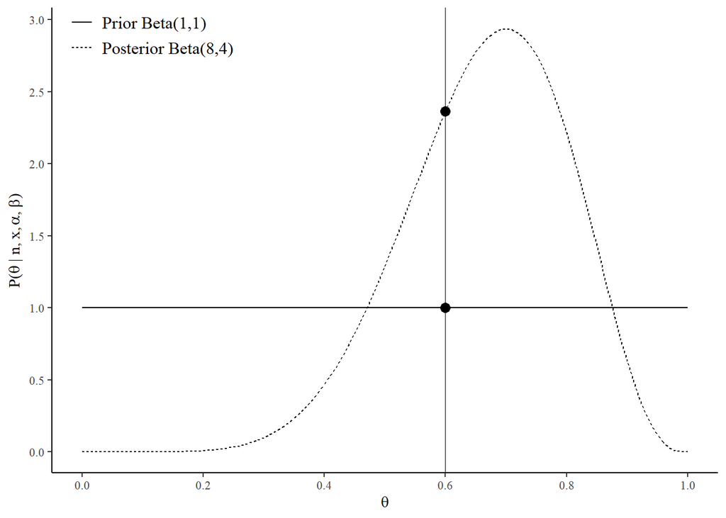

```r
beta_plot <-
  ggplot() +
  geom_function(fun = dbeta,
                args = list(shape1 = 1, shape2 = 1),
                mapping = aes(linetype = "1")) +
  geom_function(fun = dbeta,
                args = list(shape1 = 8, shape2 = 4),
                mapping = aes(linetype = "2")) +
  geom_vline(xintercept = 0.6, size = 0.3) +
  geom_point(aes(x = c(0.6, 0.6),
                 y = c(dbeta(0.6, 1, 1), dbeta(0.6, 8, 4))),
             size = 3) +
  xlab(expression(theta)) +
  ylab(expression(paste("P(", theta, " | n, x, ", alpha, ", ", beta, ")"))) +
  theme_classic() +
  scale_linetype_discrete(labels = c("Prior Beta(1,1)", "Posterior Beta(8,4)")) +
  theme(legend.position = c(0.15, 0.95),
        legend.title = element_blank(),
        legend.text  = element_text(family = "Times New Roman", size = 12),
        axis.text  = element_text(family = "Times New Roman"),
        axis.title = element_text(family = "Times New Roman")) +
  scale_x_continuous(breaks = 0:5*0.2,
                     limits = c(0,1)) +
  scale_y_continuous(breaks = 0:6*0.5)

beta_plot
```

```r
if (params$save) {ggsave(filename = "Figures/betaplot.pdf",
                         beta_plot, device = cairo_pdf, dpi = 1000)}
```

# Table 2 - Section 2.3

We kept the success probability fixed at 0.7, but increased the sample size of the individual study to show what happens with the combined *Bayesian Evidence Synthesis* Bayes Factor, when evaluating the informative hypothesis $H_i: \theta > 0.6$ against an uninformative, unconstrained hypothesis $H_u: \theta$, against its complement $H_c: \theta < 0.6$ and against a classical null hypothesis $H_0: \theta = 0.6$.

```r
n_rep <- c(10, 20, 40, 80, 100, 500, 1000)

BF_iu <- (1 - pbeta(0.6, 0.7 * n_rep + 1, 0.3 * n_rep + 1)) / 0.4
BF_ic <- BF_iu / (pbeta(0.6, 0.7 * n_rep + 1, 0.3 * n_rep + 1) / 0.6)
BF_i0 <- BF_iu / dbeta(0.6, 0.7 * n_rep + 1, 0.3 * n_rep + 1)

BFs <- cbind(BF_iu, BF_ic, BF_i0) %>% t()
colnames(BFs) <- as.character(n_rep)
round(BFs, 2) %>% knitr::kable()
```

|  | 10 | 20 | 40 | 80 | 100 | 500 | 1000 |
| --- | --- | --- | --- | --- | --- | --- | --- |
| BF_iu | 1.76 | 2.00 | 2.24 | 2.41 | 2.45 | 2.50 | 2.500000e+00 |
| BF_ic | 3.56 | 5.99 | 12.72 | 41.53 | 70.69 | 818183.03 | 5.571582e+10 |
| BF_i0 | 0.74 | 0.77 | 0.95 | 1.73 | 2.42 | 6289.62 | 2.182596e+08 |

# Plots section 3

## BES and BSU

The first three plots show what BES actually does, especially compared to BSU, when evaluating the informative hypothesis $H_i: \theta > 0.6$ against an uninformative, unconstrained hypothesis $H_u: \theta$, against its complement $H_c: \theta < 0.6$ and against a classical null hypothesis $H_0: \theta = 0.6$. These are showed first. Note that the effect size (i.e., the true success probability) equals $\Theta = 0.7$. We update the evidence using five “studies” each with the exact success probability $\Theta = 0.7$ in every sample, and a sample size of $n = 20$.

### BES versus BSU – $BF_{i,u}$

The first plot shows what happens when using Bayesian Evidence Synthesis and Bayesian Sequential Updating when evaluating the informative hypothesis $H_i: \theta > 0.6$ versus an unconstrained hypothesis $H_u: \theta$, when the observed success probability in every study is fixed at $\Theta = 0.7$.

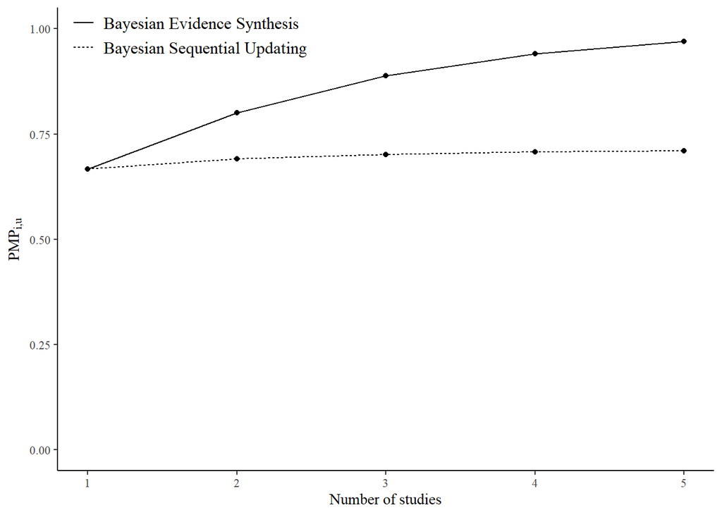

```r
## number of studies
nstudies <- 1:5

## sample size per study
n <- 20

ntotal <- nstudies * n

## Bayesian sequential updating informative hypothesis (p > 0.6)
## versus unconstrained hypothesis
bsu_iu_7 <- (1 - pbeta(0.6, 0.7 * ntotal + 1, 0.3 * ntotal + 1)) / 0.4

## Bayesian evidence synthesis of informative hypothesis (p > 0.6) versus
## the unconstrained hypothesis
bes_iu_7    <- bsu_iu_7[1] ^ {1:length(nstudies)}

## Collect the study information in a single tibble for plotting
collect <- function(studies, bsu, bes) {
  tibble(`Number of studies` = studies,
         `Bayesian Sequential Updating_PMP` = bsu / (1 + bsu),
         `Bayesian Evidence Synthesis_PMP` = bes / (1 + bes)) %>%
    pivot_longer(cols = -`Number of studies`,
                 names_to = c("Method", ".value"),
                 names_sep = "_")
}

plot.bsu.bes.pmp <- function(collection) {
  collection %>%
    ggplot(aes(x = `Number of studies`, y = PMP, linetype = Method)) +
    geom_line() +
    geom_point() +
    theme_classic() +
    theme(legend.position = c(0.2, 0.95),
          legend.title = element_blank(),
          legend.text  = element_text(family = "Times New Roman", size = 12),
          axis.text  = element_text(family = "Times New Roman"),
          axis.title = element_text(family = "Times New Roman")) +
    ylim(0,1)
}



bes_bsu_7_Hiu_pmp <- collect(nstudies, bsu_iu_7, bes_iu_7) %>%
  plot.bsu.bes.pmp() +
  ylab(expression(PMP["i,u"]))


bes_bsu_7_Hiu_pmp
```

```r
if (params$save) ggsave(filename = "Figures/bes_bsu_7_Hiu_pmp.pdf",
                        plot = bes_bsu_7_Hiu_pmp,
                        device = cairo_pdf,
                        dpi = 1000)
```

### BES versus BSU – $BF_{i,c}$

The second plot shows what happens when using Bayesian Evidence Synthesis and Bayesian Sequential Updating when evaluating the informative hypothesis $H_i: \theta > 0.6$ versus its complement $H_c: \theta < 0.6$, when the observed success probability in every study is fixed at $\Theta = 0.7$.

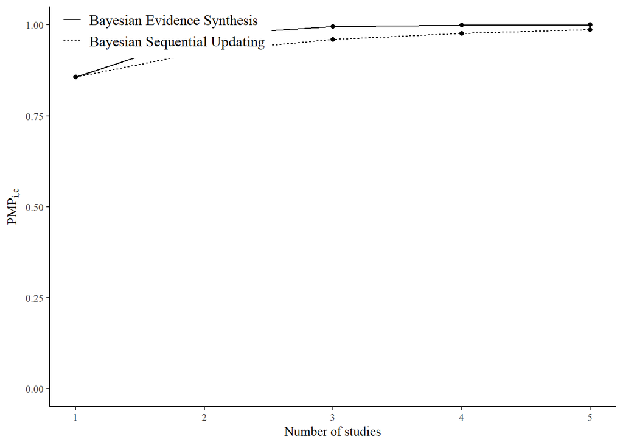

```r
## Plot Hic

## Bayesian sequential updating informative hypothesis (p > 0.6)
## versus complement (p < 0.6)
bsu_ic_7 <- bsu_iu_7 / (pbeta(0.6, 0.7 * ntotal + 1, 0.3 * ntotal + 1) / 0.6)

## Bayesian evidence synthesis of informative hypothesis (p > 0.6)
## versus its complement (p < 0.6)
bes_ic_7 <- bsu_ic_7[1] ^ {1:length(nstudies)}

bes_bsu_7_Hic_pmp <- collect(nstudies, bsu_ic_7, bes_ic_7) %>%
  plot.bsu.bes.pmp() +
  ylab(expression(PMP["i,c"]))

bes_bsu_7_Hic_pmp
```

```r
## Save the plot

if (params$save) ggsave(filename = "Figures/bes_bsu_7_Hic_pmp.pdf",
                        plot = bes_bsu_7_Hic_pmp,
                        device = cairo_pdf,
                        dpi = 1000)
```

### BES versus BSU – $BF_{i,0}$

The third plot shows what happens when using Bayesian Evidence Synthesis and Bayesian Sequential Updating when evaluating the informative hypothesis $H_i: \theta > 0.6$ versus a null hypothesis $H_0: \theta = 0.6$, when the observed success probability in every study is fixed at $\Theta = 0.7$.

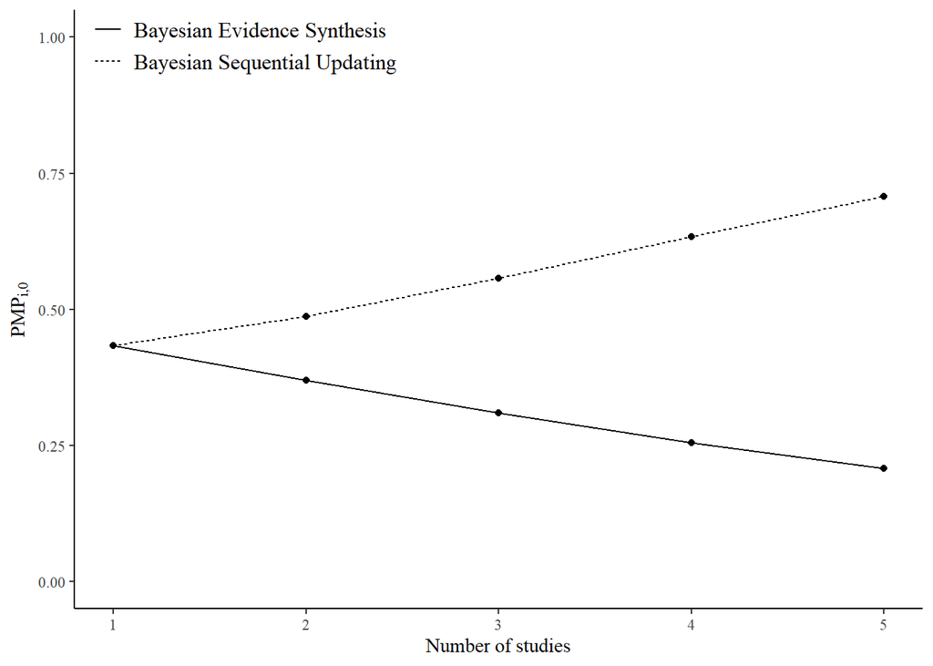

```r
bsu_i0_7 <- bsu_iu_7 / dbeta(0.6, 0.7 * ntotal + 1, 0.3 * ntotal + 1)
bes_i0_7 <- bsu_i0_7[1] ^ {1:length(nstudies)}


bes_bsu_7_Hi0_pmp <- collect(nstudies, bsu_i0_7, bes_i0_7) %>%
  plot.bsu.bes.pmp() +
  ylab(expression(PMP["i,0"]))

bes_bsu_7_Hi0_pmp
```

```r
if (params$save) ggsave(filename = "Figures/bes_bsu_7_Hi0_pmp.pdf",
                        plot = bes_bsu_7_Hi0_pmp,
                        device = cairo_pdf,
                        dpi = 1000)
```

### BES versus BSU – Combine plots

A combination of the plots can be made using `facet_grid`, which is a function from the `ggplot2` package. However, before we can do this, we have to combine the data that is previously created in a single `tibble`, with an appropriate label that is set to represent the hypotheses under consideration.

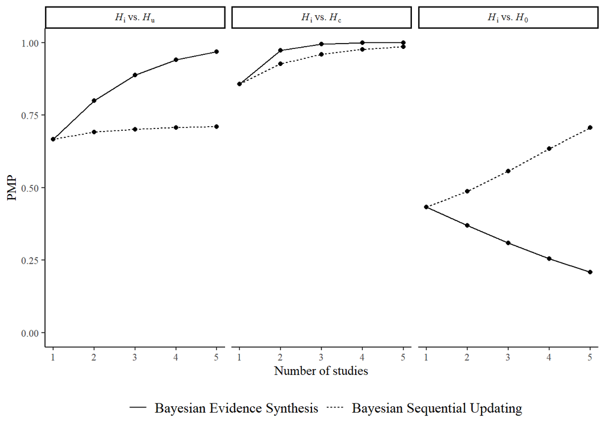

```r
## Combine the three datasets
bfs7 <- bind_rows(collect(nstudies, bsu_iu_7, bes_iu_7),
                  collect(nstudies, bsu_ic_7, bes_ic_7),
                  collect(nstudies, bsu_i0_7, bes_i0_7),
                  .id = "Hypothesis")

bes_bsu_7_pmp <- bfs7 %>%
  mutate(Hypothesis = recode_factor(Hypothesis,
                                    `1` = paste(expression(italic(H)["i"]~vs.~italic(H)["u"])),
                                    `2` = paste(expression(italic(H)["i"]~vs.~italic(H)["c"])),
                                    `3` = paste(expression(italic(H)["i"]~vs.~italic(H)["0"])))) %>%
  plot.bsu.bes.pmp() +
  facet_grid(~Hypothesis, labeller = label_parsed) +
  ylab(expression(PMP)) +
  theme(legend.position = "bottom",
        strip.text.x = element_text(family = "Times New Roman"))

bes_bsu_7_pmp
```

```r
if (params$save) ggsave(filename = "Figures/bes_bsu_7_pmp.pdf",
                        plot = bes_bsu_7_pmp,
                        device = cairo_pdf,
                        dpi = 1000)
```

## The effect of different alternatives

### Effect size = 0.8 – BSU

This plot shows what happens when using Bayesian Sequential Updating when evaluating the informative hypothesis $H_i: \theta > 0.6$ versus the unconstrained hypothesis $H_u: \theta$, the complement $H_c: \theta < 0.6$ and the null hypothesis $H_0: \theta = 0.6$, when the observed success probability in every study is fixed at $\Theta = 0.8$.

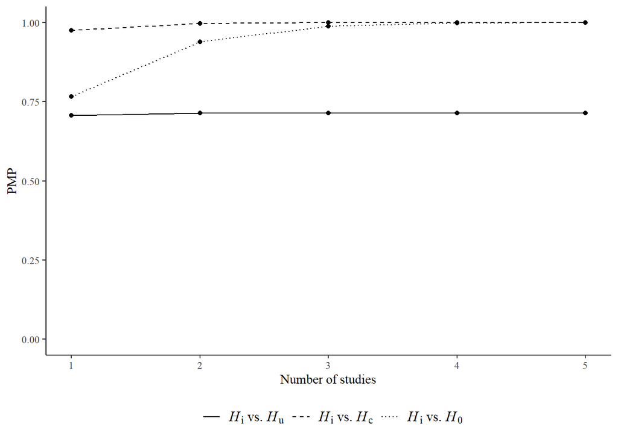

```r
collect.alternative <- function(studies, iu, ic, i0) {
  tibble(`Number of studies` = studies,
         `BF_iu` = iu,
         `BF_ic` = ic,
         `BF_i0` = i0,
         `PMP_iu` = iu / (1 + iu),
         `PMP_ic` = ic / (1 + ic),
         `PMP_i0` = i0 / (1 + i0)) %>%
    pivot_longer(cols = !`Number of studies`,
                 names_to = c(".value", "Alternative"),
                 names_sep = "_",
                 values_to = ".value") %>%
    mutate(Alternative = factor(Alternative,
                                levels = c("iu", "ic", "i0"),
                                labels = c(paste(expression(italic(H)["i"]~vs.~italic(H)["u"])),
                                           paste(expression(italic(H)["i"]~vs.~italic(H)["c"])),
                                           paste(expression(italic(H)["i"]~vs.~italic(H)["0"]))),
                                ordered = TRUE))
}

plot.bf.alternative.pmp <- function(collection, mapping) {
    collection %>%
    ggplot(mapping = mapping) +
    geom_line() +
    geom_point() +
    theme_classic() +
    ylab(expression(PMP)) +
    ylim(0,1) +
    theme(legend.position = c(0.1, 0.9),
          legend.title = element_blank(),
          legend.text  = element_text(family = "Times New Roman", size = 12),
          axis.text  = element_text(family = "Times New Roman"),
          axis.title = element_text(family = "Times New Roman"))
}

bsu_iu_8 <- (1 - pbeta(0.6, 0.8 * ntotal + 1, 0.2 * ntotal + 1)) / 0.4
bes_iu_8 <- bsu_iu_8[1] ^ {1:length(nstudies)}

bsu_ic_8 <- bsu_iu_8 / (pbeta(0.6, 0.8 * ntotal + 1, 0.2 * ntotal + 1) / 0.6)
bes_ic_8 <- bsu_ic_8[1] ^ {1:length(nstudies)}

bsu_i0_8    <- bsu_iu_8 / dbeta(0.6, 0.8 * ntotal + 1, 0.2 * ntotal + 1)
bes_i0_8    <- bsu_i0_8[1] ^ {1:length(nstudies)}




bsu_8_pmp <- collect.alternative(nstudies, bsu_iu_8, bsu_ic_8, bsu_i0_8) %>%
  plot.bf.alternative.pmp(mapping = aes(x = `Number of studies`,
                                    y = PMP,
                                    linetype = Alternative)) +
  scale_linetype_manual(values = c(1,2,3),
                        labels = scales::parse_format()) +
  theme(legend.position = "bottom")

bsu_8_pmp
```

```r
if (params$save) ggsave(filename = "Figures/bsu_8_pmp.pdf",
                        plot = bsu_8_pmp,
                        device = cairo_pdf,
                        dpi = 1000)
```

### Effect size = 0.8 – BES

This plot shows what happens when using Bayesian Evidence Synthesis when evaluating the informative hypothesis $H_i: \theta > 0.6$ versus the unconstrained hypothesis $H_u: \theta$, the complement $H_c: \theta < 0.6$ and the null hypothesis $H_0: \theta = 0.6$, when the observed success probability in every study is fixed at $\Theta = 0.8$.

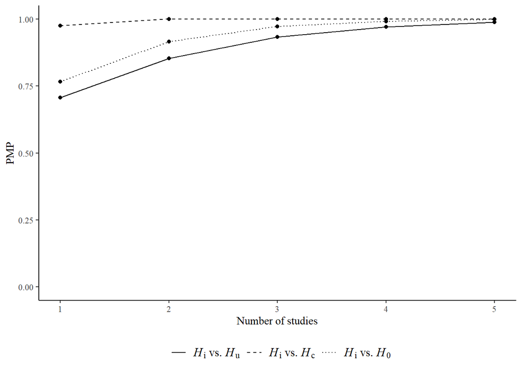

```r
bes_8_pmp <- collect.alternative(nstudies, bes_iu_8, bes_ic_8, bes_i0_8) %>%
  plot.bf.alternative.pmp(mapping = aes(x = `Number of studies`,
                                    y = PMP,
                                    linetype = Alternative)) +
  scale_linetype_manual(values = c(1,2,3),
                        labels = scales::parse_format()) +
  theme(legend.position = "bottom")


bes_8_pmp
```

```r
if (params$save) ggsave(filename = "Figures/bes_8_pmp.pdf",
                        plot = bes_8_pmp,
                        device = cairo_pdf,
                        dpi = 1000)
```

### Effect size = 0.6 – BSU

This plot shows what happens when using Bayesian Sequential Updating when evaluating the informative hypothesis $H_i: \theta > 0.6$ versus the unconstrained hypothesis $H_u: \theta$, the complement $H_c: \theta < 0.6$ and the null hypothesis $H_0: \theta = 0.6$, when the observed success probability in every study is fixed at $\Theta = 0.6$.

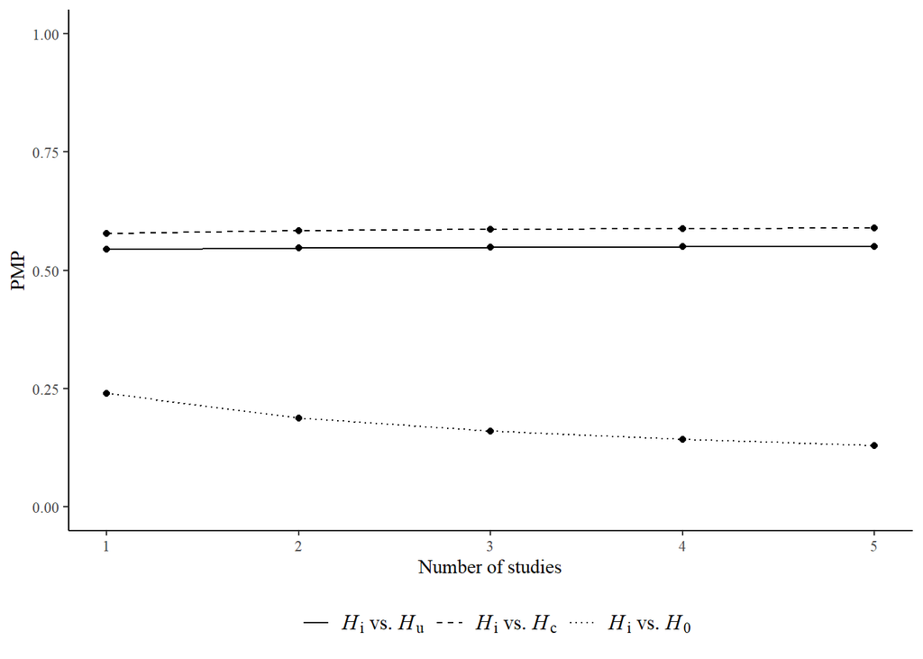

```r
bsu_iu_6 <- (1 - pbeta(0.6, 0.6 * ntotal + 1, 0.4 * ntotal + 1)) / 0.4
bes_iu_6 <- bsu_iu_6[1] ^ {1:length(nstudies)}

bsu_ic_6 <- bsu_iu_6 / (pbeta(0.6, 0.6 * ntotal + 1, 0.4 * ntotal + 1) / 0.6)
bes_ic_6 <- bsu_ic_6[1] ^ {1:length(nstudies)}

bsu_i0_6 <- bsu_iu_6 / dbeta(0.6, 0.6 * ntotal + 1, 0.4 * ntotal + 1)
bes_i0_6 <- bsu_i0_6[1] ^ {1:length(nstudies)}


bsu_6_pmp <- collect.alternative(nstudies, bsu_iu_6, bsu_ic_6, bsu_i0_6) %>%
  plot.bf.alternative.pmp(mapping = aes(x = `Number of studies`,
                                    y = PMP,
                                    linetype = Alternative)) +
  scale_linetype_manual(values = c(1,2,3),
                        labels = scales::parse_format()) +
  theme(legend.position = "bottom")

bsu_6_pmp
```

```r
if (params$save) ggsave(filename = "Figures/bsu_6_pmp.pdf",
                        plot = bsu_6_pmp,
                        device = cairo_pdf,
                        dpi = 1000)
```

### Effect size = 0.6 – BES

This plot shows what happens when using Bayesian Evidence Synthesis when evaluating the informative hypothesis $H_i: \theta > 0.6$ versus the unconstrained hypothesis $H_u: \theta$, the complement $H_c: \theta < 0.6$ and the null hypothesis $H_0: \theta = 0.6$, when the observed success probability in every study is fixed at $\Theta = 0.6$.

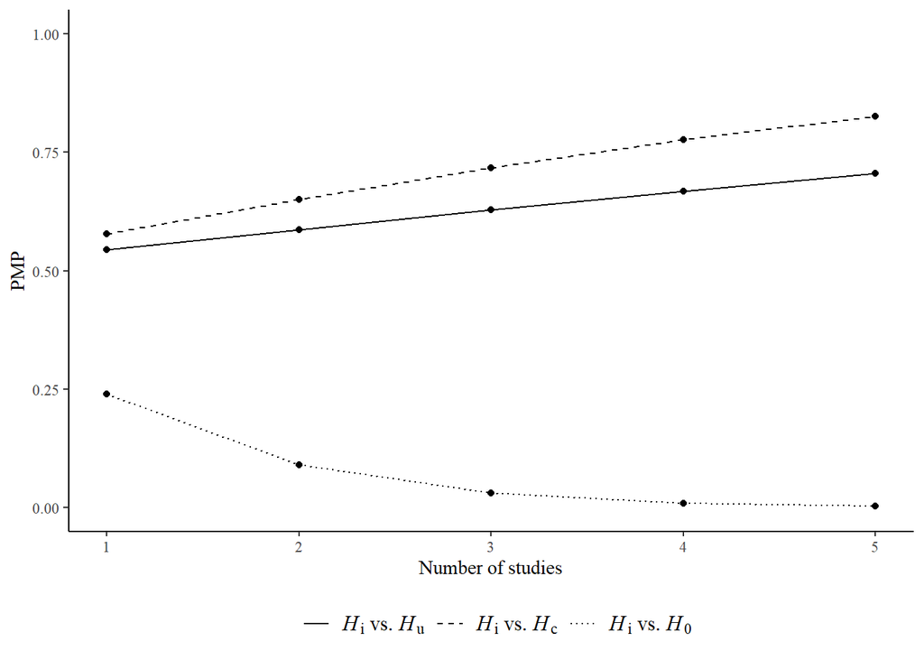

```r
bes_6_pmp <- collect.alternative(nstudies, bes_iu_6, bes_ic_6, bes_i0_6) %>%
  plot.bf.alternative.pmp(mapping = aes(x = `Number of studies`,
                                    y = PMP,
                                    linetype = Alternative)) +
  scale_linetype_manual(values = c(1,2,3),
                        labels = scales::parse_format()) +
  theme(legend.position = "bottom")

bes_6_pmp
```

```r
if (params$save) ggsave(filename = "Figures/bes_6_pmp.pdf",
                        plot = bes_6_pmp,
                        device = cairo_pdf,
                        dpi = 1000)
```

### Effect size = 0.4 – BSU

This plot shows what happens when using Bayesian Sequential Updating when evaluating the informative hypothesis $H_i: \theta > 0.6$ versus the unconstrained hypothesis $H_u: \theta$, the complement $H_c: \theta < 0.6$ and the null hypothesis $H_0: \theta = 0.6$, when the observed success probability in every study is fixed at $\Theta = 0.4$.

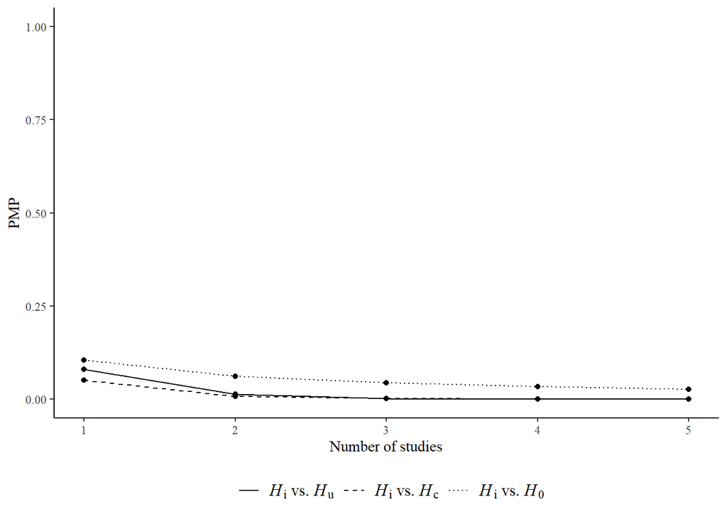

```r
bsu_iu_4 <- (1 - pbeta(0.6, 0.4 * ntotal + 1, 0.6 * ntotal + 1)) / 0.4
bes_iu_4 <- bsu_iu_4[1] ^ {1:length(nstudies)}

bsu_ic_4 <- bsu_iu_4 / (pbeta(0.6, 0.4 * ntotal + 1, 0.6 * ntotal + 1) / 0.6)
bes_ic_4 <- bsu_ic_4[1] ^ {1:length(nstudies)}

bsu_i0_4 <- bsu_iu_4 / dbeta(0.6, 0.4 * ntotal + 1, 0.6 * ntotal + 1)
bes_i0_4 <- bsu_i0_4[1] ^ {1:length(nstudies)}


bsu_4_pmp <- collect.alternative(nstudies, bsu_iu_4, bsu_ic_4, bsu_i0_4) %>%
  plot.bf.alternative.pmp(mapping = aes(x = `Number of studies`,
                                    y = PMP,
                                    linetype = Alternative)) +
  scale_linetype_manual(values = c(1,2,3),
                        labels = scales::parse_format()) +
  theme(legend.position = "bottom")

bsu_4_pmp
```

```r
if (params$save) ggsave(filename = "Figures/bsu_4_pmp.pdf",
                        plot = bsu_4_pmp,
                        device = cairo_pdf,
                        dpi = 1000)
```

### Effect size = 0.4 – BES

This plot shows what happens when using Bayesian Evidence Synthesis when evaluating the informative hypothesis $H_i: \theta > 0.6$ versus the unconstrained hypothesis $H_u: \theta$, the complement $H_c: \theta < 0.6$ and the null hypothesis $H_0: \theta = 0.6$, when the observed success probability in every study is fixed at $\Theta = 0.4$.

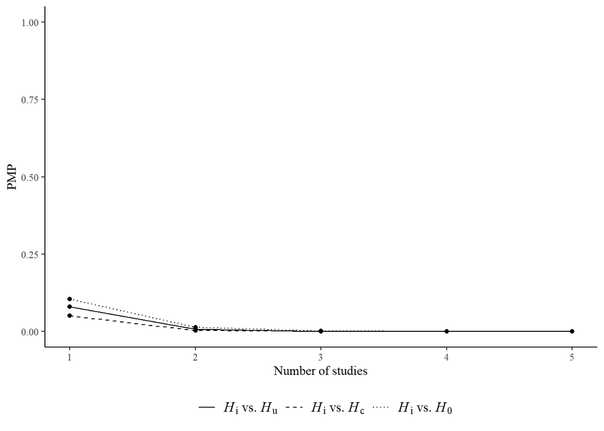

```r
bes_4_pmp <- collect.alternative(nstudies, bes_iu_4, bes_ic_4, bes_i0_4) %>%
  plot.bf.alternative.pmp(mapping = aes(x = `Number of studies`,
                                    y = PMP,
                                    linetype = Alternative)) +
  scale_linetype_manual(values = c(1,2,3),
                        labels = scales::parse_format()) +
  theme(legend.position = "bottom")

bes_4_pmp
```

```r
if (params$save) ggsave(filename = "Figures/bes_4_pmp.pdf",
                        plot = bes_4_pmp,
                        device = cairo_pdf,
                        dpi = 1000)
dat <- bind_rows(
  bind_rows(collect.alternative(nstudies, bes_iu_8, bes_ic_8, bes_i0_8),
            collect.alternative(nstudies, bes_iu_6, bes_ic_6, bes_i0_6),
            collect.alternative(nstudies, bes_iu_4, bes_ic_4, bes_i0_4),
            .id = "Theta"),
  bind_rows(collect.alternative(nstudies, bsu_iu_8, bsu_ic_8, bsu_i0_8),
            collect.alternative(nstudies, bsu_iu_6, bsu_ic_6, bsu_i0_6),
            collect.alternative(nstudies, bsu_iu_4, bsu_ic_4, bsu_i0_4),
            .id = "Theta"),
  .id = "Aggregation")

dat
```

| Aggregation | Theta | Number of studies | Alternative | BF | PMP |
| --- | --- | --- | --- | --- | --- |
| 1 | 1 | 1 | italic(H)["i"] ~ vs. ~ italic(H)["u"] | 2.407611e+00 | 7.065393e-01 |
| 1 | 1 | 1 | italic(H)["i"] ~ vs. ~ italic(H)["c"] | 3.908921e+01 | 9.750556e-01 |
| 1 | 1 | 1 | italic(H)["i"] ~ vs. ~ italic(H)["0"] | 3.276523e+00 | 7.661652e-01 |
| 1 | 1 | 2 | italic(H)["i"] ~ vs. ~ italic(H)["u"] | 5.796590e+00 | 8.528674e-01 |
| 1 | 1 | 2 | italic(H)["i"] ~ vs. ~ italic(H)["c"] | 1.527966e+03 | 9.993460e-01 |
| 1 | 1 | 2 | italic(H)["i"] ~ vs. ~ italic(H)["0"] | 1.073560e+01 | 9.147892e-01 |
| 1 | 1 | 3 | italic(H)["i"] ~ vs. ~ italic(H)["u"] | 1.395593e+01 | 9.331369e-01 |
| 1 | 1 | 3 | italic(H)["i"] ~ vs. ~ italic(H)["c"] | 5.972698e+04 | 9.999833e-01 |
| 1 | 1 | 3 | italic(H)["i"] ~ vs. ~ italic(H)["0"] | 3.517546e+01 | 9.723570e-01 |
| 1 | 1 | 4 | italic(H)["i"] ~ vs. ~ italic(H)["u"] | 3.360046e+01 | 9.710986e-01 |

[output cut: 80 more lines]

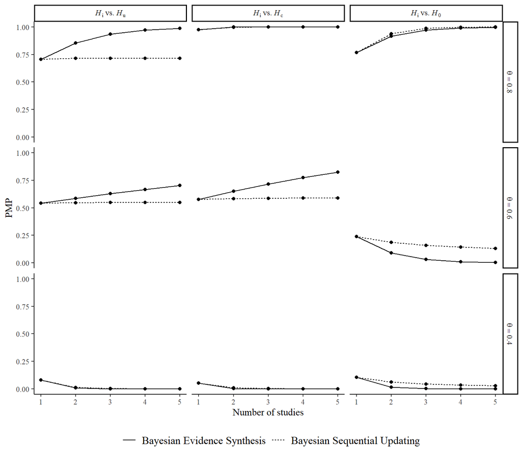

```r
bes_bsu_pmp <- dat %>%
  mutate(Aggregation = recode_factor(Aggregation,
                                     `1` = "Bayesian Evidence Synthesis",
                                     `2` = "Bayesian Sequential Updating"),
         Theta       = recode_factor(Theta,
                                     `1` = paste(expression(theta==0.8)),
                                     `2` = paste(expression(theta==0.6)),
                                     `3` = paste(expression(theta==0.4)))) %>%
  plot.bf.alternative.pmp(mapping = aes(x = `Number of studies`,
                                    y = PMP,
                                    linetype = Aggregation)) +
  facet_grid(Theta ~ Alternative,
             labeller = label_parsed) +
  theme(strip.text.x = element_text(family = "Times New Roman"),
        strip.text.y = element_text(family = "Times New Roman"),
        legend.position = "bottom",
        legend.background = element_rect(fill = "transparent"),
        legend.title = element_blank()) #+
  #geom_hline(yintercept = c(-3:3 * 5), colour = "grey", size = 0.1)

bes_bsu_pmp
```

```r
if (params$save) ggsave(filename = "Figures/bes_bsu_pmp.pdf",
                        plot = bes_bsu_pmp,
                        device = cairo_pdf,
                        dpi = 1000)
```

# Small simulation section 4

First, we set the seed for reproducibility of our results and load the required packages.

```r
## Set seed
set.seed(123)

# Load packages
library(tidyverse)
library(magrittr)
library(furrr)
library(BFpack)
library(Rcpp)
library(RcppArmadillo)
# devtools::build("DataCpp")
# devtools::install("DataCpp")
library(DataCpp)
```

Then, we load the required functions to generate the simulated data.

```r
source("functions.R")
```

We also specify parallel processing to speed up the simulation, and specify the future seed (also for reproducibility).

```r
## Parallel processing
plan(multisession)

## Parallel seed
options <- furrr_options(seed = TRUE)
```

## Simulation 1

We run our simulations for 1000 iterations.

```r
################################################################################
## Specify simulation conditions
################################################################################

## Number of simulations
nsim <- 1000

## Sample sizes
n <- 50 * 2^{0:4}

## Models
models <- c("normal", "logit", "probit")

## r2 of the regression model
r2 <- c(.02, .09, .25)

## Specify relative importance of the regression coefficients
ratio_beta <- c(1,1,1,2,3)

## Specify the bivariate correlations between predictors
pcor <- c(0.3)
```

To test whether the simulated data sets agree with our specifications, we test the specifications for all three different data generating models.

```r
gen_dat(0.02,
        coefs(0.02, ratio_beta, cormat(pcor, length(ratio_beta)), "normal"),
        cormat(pcor, length(ratio_beta)),
        100000,
        "normal") %$%
  lm(Y ~ V1 + V2 + V3 + V4 + V5) %>%
  summary()
```

```
##
## Call:
## lm(formula = Y ~ V1 + V2 + V3 + V4 + V5)
##
## Residuals:
##     Min      1Q  Median      3Q     Max
## -4.1066 -0.6638 -0.0010  0.6678  4.2713
##
## Coefficients:
##              Estimate Std. Error t value Pr(>|t|)
## (Intercept) 0.0009564  0.0031296   0.306     0.76
## V1          0.0302735  0.0034697   8.725  < 2e-16 ***
## V2          0.0212009  0.0034794   6.093 1.11e-09 ***
## V3          0.0261024  0.0034697   7.523 5.40e-14 ***
## V4          0.0592716  0.0034755  17.054  < 2e-16 ***
## V5          0.0691763  0.0034812  19.872  < 2e-16 ***
## ---
## Signif. codes:  0 '***' 0.001 '**' 0.01 '*' 0.05 '.' 0.1 ' ' 1
##
## Residual standard error: 0.9897 on 99994 degrees of freedom
## Multiple R-squared:  0.02019,    Adjusted R-squared:  0.02014
## F-statistic:   412 on 5 and 99994 DF,  p-value: < 2.2e-16
```

```r
coefs(0.02, ratio_beta, cormat(pcor, length(ratio_beta)), "normal")
```

```
## [1] 0.02564946 0.02564946 0.02564946 0.05129892 0.07694838
```

```r
gen_dat(0.09,
        coefs(0.09, ratio_beta, cormat(pcor, length(ratio_beta)), "logit"),
        cormat(pcor, length(ratio_beta)),
        100000,
        "logit") %$%
  glm(Y ~ V1 + V2 + V3 + V4 + V5, family = binomial(link = "logit")) %T>%
  {performance::r2_mckelvey(.) %>% print()} %>%
  summary()
```

```
## McKelvey's R2
##    0.08720598
```

```
##
## Call:
## glm(formula = Y ~ V1 + V2 + V3 + V4 + V5, family = binomial(link = "logit"))
##
## Deviance Residuals:
##     Min       1Q   Median       3Q      Max
## -2.0869  -1.1164   0.5416   1.1149   2.2943
##
## Coefficients:
##              Estimate Std. Error z value Pr(>|z|)
## (Intercept) -0.000295   0.006553  -0.045    0.964
## V1           0.095322   0.007297  13.063   <2e-16 ***
## V2           0.102285   0.007301  14.009   <2e-16 ***
## V3           0.098876   0.007300  13.546   <2e-16 ***
## V4           0.210972   0.007339  28.748   <2e-16 ***
## V5           0.304250   0.007396  41.139   <2e-16 ***
## ---
## Signif. codes:  0 '***' 0.001 '**' 0.01 '*' 0.05 '.' 0.1 ' ' 1
##
## (Dispersion parameter for binomial family taken to be 1)
##
##     Null deviance: 138629  on 99999  degrees of freedom
## Residual deviance: 131569  on 99994  degrees of freedom
## AIC: 131581
##
## Number of Fisher Scoring iterations: 4
```

```r
coefs(0.09, ratio_beta, cormat(pcor, length(ratio_beta)), "logit")
```

```
## [1] 0.1034554 0.1034554 0.1034554 0.2069107 0.3103661
```

```r
gen_dat(0.25,
        coefs(0.25, ratio_beta, cormat(pcor, length(ratio_beta)), "probit"),
        cormat(pcor, length(ratio_beta)),
        100000,
        "probit") %$%
  glm(Y ~ V1 + V2 + V3 + V4 + V5, family = binomial(link = "probit")) %T>%
  {performance::r2_mckelvey(.) %>% print()} %>%
  summary()
```

```
## McKelvey's R2
##     0.2512146
```

```
##
## Call:
## glm(formula = Y ~ V1 + V2 + V3 + V4 + V5, family = binomial(link = "probit"))
##
## Deviance Residuals:
##     Min       1Q   Median       3Q      Max
## -2.7002  -1.0266  -0.2485   1.0278   2.5652
##
## Coefficients:
##              Estimate Std. Error z value Pr(>|z|)
## (Intercept) -0.003193   0.004189  -0.762    0.446
## V1           0.102129   0.004669  21.874   <2e-16 ***
## V2           0.106003   0.004681  22.647   <2e-16 ***
## V3           0.112324   0.004668  24.065   <2e-16 ***
## V4           0.207654   0.004709  44.102   <2e-16 ***
## V5           0.314596   0.004811  65.395   <2e-16 ***
## ---
## Signif. codes:  0 '***' 0.001 '**' 0.01 '*' 0.05 '.' 0.1 ' ' 1
##
## (Dispersion parameter for binomial family taken to be 1)
##
##     Null deviance: 138629  on 99999  degrees of freedom
## Residual deviance: 121211  on 99994  degrees of freedom
## AIC: 121223
##
## Number of Fisher Scoring iterations: 3
```

```r
coefs(0.25, ratio_beta, cormat(pcor, length(ratio_beta)), "probit")
```

```
## [1] 0.1047135 0.1047135 0.1047135 0.2094270 0.3141404
```

These tests do not indicate any misspecifications.

```r
sim1 <-
  expand_grid(nsim = 1:nsim,
              n = n,
              pcor = pcor,
              r2 = r2,
              model = models) %>%
  mutate(rho   = map(pcor, ~cormat(.x, length(ratio_beta))),
         betas = pmap(list(r2, rho, model),                   # calculate regression
                      function(r2, rho, model) {              # coefficients given
                        coefs(r2, ratio_beta, rho, model)     # model specifications
                      }),
         fit = future_pmap(list(r2, betas, rho, n, model),
                           function(r2, betas, rho, n, model) {
                             data_and_model(r2 = r2,
                                            betas = betas,
                                            rho = rho,
                                            n = n,
                                            model = model,
                                            formula = Y ~ V1 + V2 + V3 + V4 + V5,
                                            hypothesis = "V3 < V4 < V5")
         }, .options = options))

saveRDS(sim1, file = "simulation-results/sim1.rds")
```

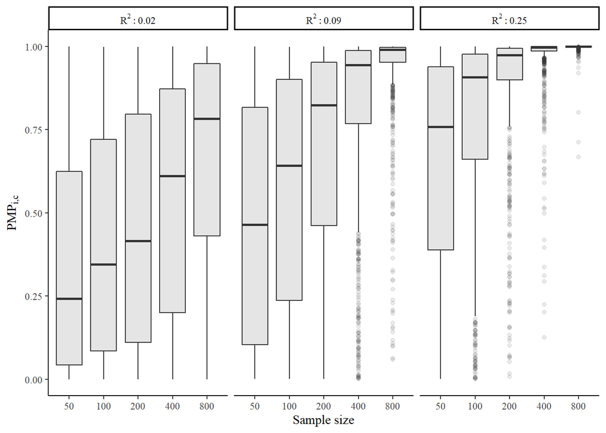

```r
sim1_plot_box <- sim1 %>%
  mutate(bf_iu = map_dbl(fit, ~.x[1,7]),
         bf_cu = map_dbl(fit, ~.x[2,7]),
         bf_ic = bf_iu / bf_cu) %>%
  group_by(nsim, n, r2) %>%
  summarize(across(.cols = starts_with("bf_"), .fns = ~prod(.x))) %>%
  mutate(pmp_iu = bf_iu / (bf_iu + 1),
         pmp_ic = bf_iu / (bf_iu + bf_cu),
         r2 = paste0("R^2: ", r2)) %>%
  ggplot(aes(x = as.factor(n), y = pmp_ic)) +
  geom_boxplot(fill = "black", alpha = 0.1) +
  facet_wrap(~r2, labeller = label_parsed) +
  theme_classic() +
  labs(y = expression(PMP["i,c"]),
       x = "Sample size") +
  theme(text = element_text(family = "Times New Roman")) +
  ylim(0,1)
sim1_plot_box
```

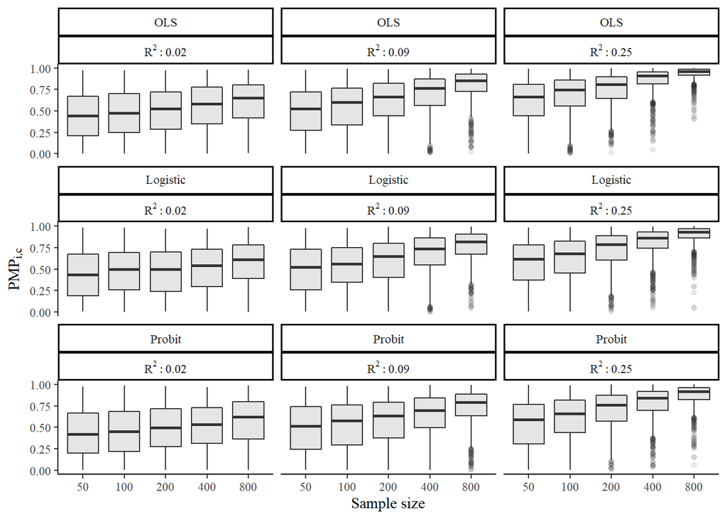

```r
sim1_sep_plot_box <- sim1 %>%
  mutate(bf_iu = map_dbl(fit, ~.x[1,7]),
         bf_cu = map_dbl(fit, ~.x[2,7]),
         bf_ic = bf_iu / bf_cu,
         pmp_iu = bf_iu / (bf_iu + 1),
         pmp_ic = bf_iu / (bf_iu + bf_cu),
         r2 = paste0("R^2: ", r2),
         model = factor(model,
                        levels = c("normal", "logit", "probit"),
                        labels = c("OLS", "Logistic", "Probit"))) %>%
  ggplot(aes(x = as.factor(n), y = pmp_ic)) +
  geom_boxplot(fill = "black", alpha = 0.1) +
  facet_wrap(model~r2, labeller = label_parsed) +
  theme_classic() +
  labs(y = expression(PMP["i,c"]),
       x = "Sample size") +
  theme(text = element_text(family = "Times New Roman")) +
  ylim(0,1)

sim1_sep_plot_box
```

```r
if (params$save) ggsave(filename = "Figures/sim1_box.pdf",
                        plot = sim1_plot_box,
                        device = cairo_pdf,
                        dpi = 1000,
                        height = 3)
if (params$save) ggsave(filename = "Figures/sim1_sep_box.pdf",
                        plot = sim1_sep_plot_box,
                        device = cairo_pdf,
                        dpi = 1000,
                        height = 7)
```

## Simulation 2

In simulation 2, we build on simulation 1, in the sense that we use the same statistical models. However, now we also vary the operationalization of the independent variables. Specifically, in the linear model data, we consider three continuous predictors of equal size, that are all expected to have a positive effect on the outcome $Y$. In the logit simulations, we combine the three variables into a single continuous variable by taking the average of these three variables, considering it as a scale score, while in the probit simulations, we break up the single continuous measure into three categories, using probit regression with dummy variables.

```r
sim2_normal <-
  expand_grid(nsim = 1:nsim,
              n = n,
              pcor = pcor,
              r2 = r2,
              model = "normal") %>%
  mutate(rho   = map(pcor, ~cormat(.x, length(ratio_beta))),
         betas = pmap(list(r2, rho, model),                   # calculate regression
                      function(r2, rho, model) {              # coefficients given
                        coefs(r2, ratio_beta, rho, model)     # model specifications
                      }),
         fit = future_pmap(list(r2, betas, rho, n, model),
                           function(r2, betas, rho, n, model) {
                             data_and_model(r2 = r2,
                                            betas = betas,
                                            rho = rho,
                                            n = n,
                                            model = model,
                                            formula = Y ~ V1 + V2 + V3 + V4 + V5,
                                            hypothesis = "V1 > 0 & V2 > 0 & V3 > 0")
         }, .options = options))

sim2_logit <-
  expand_grid(nsim = 1:nsim,
              n = n,
              pcor = pcor,
              r2 = r2,
              model = "logit") %>%
  mutate(rho   = map(pcor, ~cormat(.x, length(ratio_beta))),
         betas = pmap(list(r2, rho, model),                   # calculate regression
                      function(r2, rho, model) {              # coefficients given
                        coefs(r2, ratio_beta, rho, model)     # model specifications
                      }),
         fit = future_pmap(list(r2, betas, rho, n, model),
                           function(r2, betas, rho, n, model) {
                             data_and_model(r2 = r2,
                                            betas = betas,
                                            rho = rho,
                                            n = n,
                                            model = model,
                                            mutate_args = quos(Vcomb = (V1 + V2 + V3)/3),
                                            formula = Y ~ Vcomb + V4 + V5,
                                            hypothesis = "Vcomb > 0")
         }, .options = options))


sim2_probit <-
  expand_grid(nsim = 1:nsim,
              n = n,
              pcor = pcor,
              r2 = r2,
              model = "probit") %>%
  mutate(rho   = map(pcor, ~cormat(.x, length(ratio_beta))),
         betas = pmap(list(r2, rho, model),                   # calculate regression
                      function(r2, rho, model) {              # coefficients given
                        coefs(r2, ratio_beta, rho, model)     # model specifications
                      }),
         fit = future_pmap(list(r2, betas, rho, n, model),
                           function(r2, betas, rho, n, model) {
                             data_and_model(r2 = r2,
                                            betas = betas,
                                            rho = rho,
                                            n = n,
                                            model = model,
                                            mutate_args = quos(Dummy = cut((V1 + V2 + V3)/3,
                                                                           3, labels = 1:3)),
                                            formula = Y ~ Dummy - 1 + V4 + V5,
                                            hypothesis = "Dummy1 < Dummy2 < Dummy3")
         }, .options = options))

sim2 <- bind_rows(sim2_normal, sim2_logit, sim2_probit)

saveRDS(sim2, file = "simulation-results/sim2.rds")
```

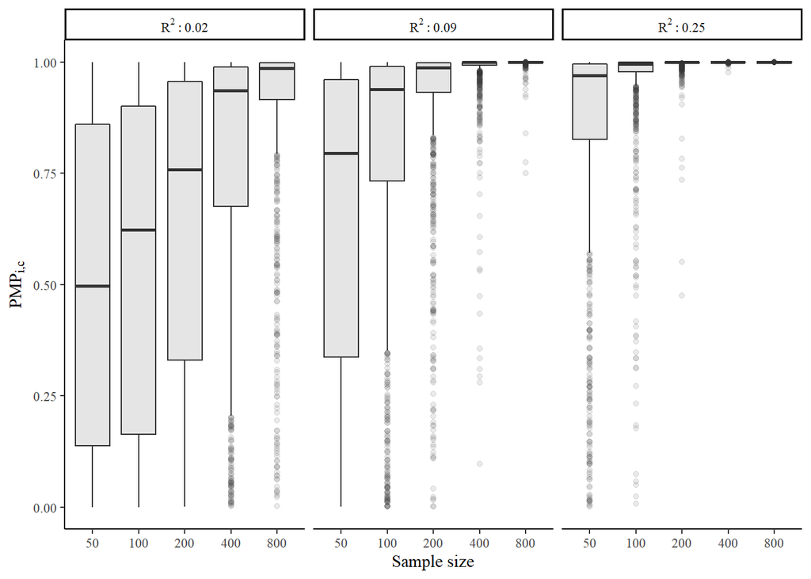

```r
sim2_plot_box <- sim2 %>%
  mutate(bf_iu = map_dbl(fit, ~.x[1,7]),
         bf_cu = map_dbl(fit, ~.x[2,7]),
         bf_ic = bf_iu / bf_cu) %>%
  group_by(nsim, n, r2) %>%
  summarize(across(.cols = starts_with("bf_"), .fns = ~prod(.x))) %>%
  mutate(pmp_iu = bf_iu / (bf_iu + 1),
         pmp_ic = bf_iu / (bf_iu + bf_cu),
         r2 = paste0("R^2: ", r2)) %>%
  ggplot(aes(x = as.factor(n), y = pmp_ic)) +
  geom_boxplot(fill = "black", alpha = 0.1) +
  facet_wrap(~r2, labeller = label_parsed) +
  theme_classic() +
  labs(y = expression(PMP["i,c"]),
       x = "Sample size") +
  theme(text = element_text(family = "Times New Roman")) +
  ylim(0,1)
sim2_plot_box
```

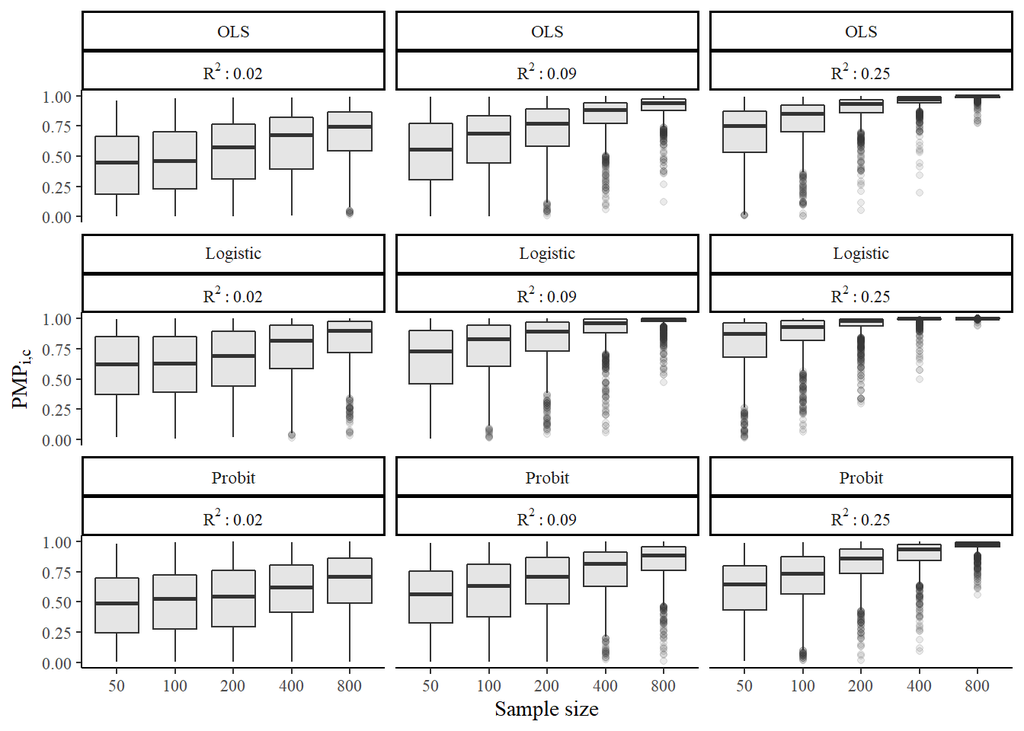

```r
sim2_sep_plot_box <- sim2 %>%
  mutate(bf_iu = map_dbl(fit, ~.x[1,7]),
         bf_cu = map_dbl(fit, ~.x[2,7]),
         bf_ic = bf_iu / bf_cu,
         pmp_iu = bf_iu / (bf_iu + 1),
         pmp_ic = bf_iu / (bf_iu + bf_cu),
         r2 = paste0("R^2: ", r2),
         model = factor(model,
                        levels = c("normal", "logit", "probit"),
                        labels = c("OLS", "Logistic", "Probit"))) %>%
  ggplot(aes(x = as.factor(n), y = pmp_ic)) +
  geom_boxplot(fill = "black", alpha = 0.1) +
  facet_wrap(model~r2, labeller = label_parsed) +
  theme_classic() +
  labs(y = expression(PMP["i,c"]),
       x = "Sample size") +
  theme(text = element_text(family = "Times New Roman")) +
  ylim(0,1)

sim2_sep_plot_box
```

```r
sim12 <- bind_rows(sim1, sim2, .id = "Simulation") %>%
  mutate(r2 = paste0("$R^2 = ", r2, "$"),
         bf_iu = map_dbl(fit, ~.x[1,7]),
         bf_cu = map_dbl(fit, ~.x[2,7]),
         bf_ic = bf_iu / bf_cu)

summ_sim12 <- sim12 %>%
  group_by(Simulation, nsim, n, r2) %>%
  summarize(across(.cols = starts_with("bf_"), .fns = ~prod(.x))) %>%
  mutate(model = "Aggregated")
full_join(sim12, summ_sim12) %>%
  ungroup() %>%
  filter(r2 == "$R^2 = 0.02$" | r2 == "$R^2 = 0.25$",
         n %in% c(50, 200, 800)) %>%
  mutate(pmp_iu = bf_iu / (bf_iu + 1),
         pmp_ic = bf_iu / (bf_iu + bf_cu),
         model = factor(model,
                        levels = c("normal", "logit", "probit", "Aggregated"),
                        labels = c("OLS", "Logistic", "Probit", "Aggregated")),
         `Sample size` = n) %>%
  group_by(Simulation, r2, `Sample size`, model) %>%
  summarize(PMP_median = median(pmp_ic)) %>%
  pivot_wider(names_from = model, values_from = PMP_median) %>%
  xtable::xtable()
```

[output not shown]

| Simulation | r2 | Sample size | OLS | Logistic | Probit | Aggregated |
| --- | --- | --- | --- | --- | --- | --- |
| 1 | $R^2 = 0.02$ | 50 | 0.4448636 | 0.4320893 | 0.4190902 | 0.2418200 |
| 1 | $R^2 = 0.02$ | 200 | 0.5226420 | 0.4971069 | 0.4977954 | 0.4151845 |
| 1 | $R^2 = 0.02$ | 800 | 0.6497450 | 0.6091395 | 0.6205695 | 0.7832247 |
| 1 | $R^2 = 0.25$ | 50 | 0.6624306 | 0.6148828 | 0.5889932 | 0.7583901 |
| 1 | $R^2 = 0.25$ | 200 | 0.8059729 | 0.7857746 | 0.7592084 | 0.9742766 |
| 1 | $R^2 = 0.25$ | 800 | 0.9617303 | 0.9342005 | 0.9147112 | 0.9997557 |
| 2 | $R^2 = 0.02$ | 50 | 0.4476613 | 0.6226192 | 0.4871952 | 0.4964267 |
| 2 | $R^2 = 0.02$ | 200 | 0.5755573 | 0.6897607 | 0.5445217 | 0.7577780 |
| 2 | $R^2 = 0.02$ | 800 | 0.7473270 | 0.9022446 | 0.7072099 | 0.9867026 |
| 2 | $R^2 = 0.25$ | 50 | 0.7488301 | 0.8749596 | 0.6479717 | 0.9698971 |

[output cut: 2 more lines]

```r
if (params$save) ggsave(filename = "Figures/sim2_box.pdf",
                        plot = sim2_plot_box,
                        device = cairo_pdf,
                        dpi = 1000,
                        height = 3)
if (params$save) ggsave(filename = "Figures/sim2_sep_box.pdf",
                        plot = sim2_sep_plot_box,
                        device = cairo_pdf,
                        dpi = 1000,
                        height = 7)
```

— END OF DOCUMENT —